# Q3_HDPEresins

## Q3: You are requested to get the master curve of the HDPE resins at the reference temperature of T=210oC and get the complex viscosity curve at 200oC. Also, using the master curve of the $G^{\prime\prime}(\omega)$ at T=210oC , you are requested to get the First normal stress difference at steady state, for shear rates 0.1, 1, 10 and 100 1/s, using the Wagner Model. Make any comments/observations you consider important. (20 pts)

```python
%matplotlib inline

import jbr

import pandas as pd
import numpy as np
import warnings
warnings.filterwarnings('ignore')
pd.options.display.max_columns = None
```

### Let's read and look at the provided data

```python
df = pd.read_csv("./resinData.csv", delimiter=",");

df = df.reindex(sorted(df.columns), axis=1);
print("./data.csv"); display(df.head());
#display(pd.Series(df.columns));
```

```
./data.csv
```

|  | $\dot{\gamma}_{210°C}$ | $\omega_{170°C}$ | $\omega_{190°C}$ | $\omega_{210°C}$ | $\omega_{230°C}$ | ${G^{\prime\prime}(\omega)}_{170°C}$ | ${G^{\prime\prime}(\omega)}_{190°C}$ | ${G^{\prime\prime}(\omega)}_{210°C}$ | ${G^{\prime\prime}(\omega)}_{230°C}$ | ${G^{\prime}(\omega)}_{170°C}$ | ${G^{\prime}(\omega)}_{190°C}$ | ${G^{\prime}(\omega)}_{210°C}$ | ${G^{\prime}(\omega)}_{230°C}$ | ${\eta(\dot{\gamma})}_{210°C}$ |
| --- | --- | --- | --- | --- | --- | --- | --- | --- | --- | --- | --- | --- | --- | --- |
| 0 | 5000.000 | 500.000 | 500.000 | 500.000 | 500.000 | 175274.0 | 162690.0 | 169359.0 | 150515.0 | 342637.0 | 298322.0 | 288545.0 | 251301.0 | 200.000000 |
| 1 | 2000.000 | 281.172 | 281.172 | 281.172 | 281.172 | 154624.0 | 141712.0 | 146049.0 | 128738.0 | 279460.0 | 241178.0 | 231412.0 | 199744.0 | 300.000000 |
| 2 | 1000.000 | 158.117 | 158.117 | 158.117 | 158.117 | 136274.0 | 123273.0 | 124870.0 | 109503.0 | 225629.0 | 192397.0 | 182623.0 | 156375.0 | 500.000000 |
| 3 | 500.000 | 88.916 | 88.916 | 88.916 | 88.916 | 118219.0 | 105489.0 | 105000.0 | 91613.6 | 178929.0 | 150780.0 | 141545.0 | 120746.0 | 669.150769 |
| 4 | 281.172 | 50.002 | 50.002 | 50.002 | 50.002 | 100544.0 | 88490.7 | 86653.8 | 75213.8 | 139482.0 | 116194.0 | 108073.0 | 91516.8 | 973.231456 |

### Calculate:

### $$ tan \delta = \frac{G^{\prime\prime}(\omega)}{G^{\prime}(\omega)} $$

```python
df = jbr.calculate_tand(df)
df = df.reindex(sorted(df.columns), axis=1);
print("./data.csv"); display(df.head());
#display(pd.Series(df.columns));
```

```
./data.csv
```

|  | $\dot{\gamma}_{210°C}$ | $\omega_{170°C}$ | $\omega_{190°C}$ | $\omega_{210°C}$ | $\omega_{230°C}$ | ${G^{\prime\prime}(\omega)}_{170°C}$ | ${G^{\prime\prime}(\omega)}_{190°C}$ | ${G^{\prime\prime}(\omega)}_{210°C}$ | ${G^{\prime\prime}(\omega)}_{230°C}$ | ${G^{\prime}(\omega)}_{170°C}$ | ${G^{\prime}(\omega)}_{190°C}$ | ${G^{\prime}(\omega)}_{210°C}$ | ${G^{\prime}(\omega)}_{230°C}$ | ${\eta(\dot{\gamma})}_{210°C}$ | ${tan\delta}_{170°C}$ | ${tan\delta}_{190°C}$ | ${tan\delta}_{210°C}$ | ${tan\delta}_{230°C}$ |
| --- | --- | --- | --- | --- | --- | --- | --- | --- | --- | --- | --- | --- | --- | --- | --- | --- | --- | --- |
| 0 | 5000.000 | 500.000 | 500.000 | 500.000 | 500.000 | 175274.0 | 162690.0 | 169359.0 | 150515.0 | 342637.0 | 298322.0 | 288545.0 | 251301.0 | 200.000000 | 0.511544 | 0.545350 | 0.586941 | 0.598943 |
| 1 | 2000.000 | 281.172 | 281.172 | 281.172 | 281.172 | 154624.0 | 141712.0 | 146049.0 | 128738.0 | 279460.0 | 241178.0 | 231412.0 | 199744.0 | 300.000000 | 0.553296 | 0.587583 | 0.631121 | 0.644515 |
| 2 | 1000.000 | 158.117 | 158.117 | 158.117 | 158.117 | 136274.0 | 123273.0 | 124870.0 | 109503.0 | 225629.0 | 192397.0 | 182623.0 | 156375.0 | 500.000000 | 0.603974 | 0.640722 | 0.683758 | 0.700259 |
| 3 | 500.000 | 88.916 | 88.916 | 88.916 | 88.916 | 118219.0 | 105489.0 | 105000.0 | 91613.6 | 178929.0 | 150780.0 | 141545.0 | 120746.0 | 669.150769 | 0.660703 | 0.699622 | 0.741814 | 0.758730 |
| 4 | 281.172 | 50.002 | 50.002 | 50.002 | 50.002 | 100544.0 | 88490.7 | 86653.8 | 75213.8 | 139482.0 | 116194.0 | 108073.0 | 91516.8 | 973.231456 | 0.720839 | 0.761577 | 0.801808 | 0.821858 |

### Compute:

### $$ G^*(\omega) = {\left[ {G^{\prime\prime}(\omega)}^2 + {G^{\prime}(\omega)}^2 \right]}^{0.5} $$

```python
df = jbr.calculate_complexModulus(df)
df = df.reindex(sorted(df.columns), axis=1);
print("./data.csv"); display(df.head());
#display(pd.Series(df.columns));
```

```
./data.csv
```

|  | $\dot{\gamma}_{210°C}$ | $\omega_{170°C}$ | $\omega_{190°C}$ | $\omega_{210°C}$ | $\omega_{230°C}$ | ${G^{*}(\omega)}_{170°C}$ | ${G^{*}(\omega)}_{190°C}$ | ${G^{*}(\omega)}_{210°C}$ | ${G^{*}(\omega)}_{230°C}$ | ${G^{\prime\prime}(\omega)}_{170°C}$ | ${G^{\prime\prime}(\omega)}_{190°C}$ | ${G^{\prime\prime}(\omega)}_{210°C}$ | ${G^{\prime\prime}(\omega)}_{230°C}$ | ${G^{\prime}(\omega)}_{170°C}$ | ${G^{\prime}(\omega)}_{190°C}$ | ${G^{\prime}(\omega)}_{210°C}$ | ${G^{\prime}(\omega)}_{230°C}$ | ${\eta(\dot{\gamma})}_{210°C}$ | ${tan\delta}_{170°C}$ | ${tan\delta}_{190°C}$ | ${tan\delta}_{210°C}$ | ${tan\delta}_{230°C}$ |
| --- | --- | --- | --- | --- | --- | --- | --- | --- | --- | --- | --- | --- | --- | --- | --- | --- | --- | --- | --- | --- | --- | --- |
| 0 | 5000.000 | 500.000 | 500.000 | 500.000 | 500.000 | 384865.026789 | 339800.017340 | 334575.384489 | 292928.246890 | 175274.0 | 162690.0 | 169359.0 | 150515.0 | 342637.0 | 298322.0 | 288545.0 | 251301.0 | 200.000000 | 0.511544 | 0.545350 | 0.586941 | 0.598943 |
| 1 | 2000.000 | 281.172 | 281.172 | 281.172 | 281.172 | 319384.522130 | 279730.439223 | 273645.435089 | 237636.567430 | 154624.0 | 141712.0 | 146049.0 | 128738.0 | 279460.0 | 241178.0 | 231412.0 | 199744.0 | 300.000000 | 0.553296 | 0.587583 | 0.631121 | 0.644515 |
| 2 | 1000.000 | 158.117 | 158.117 | 158.117 | 158.117 | 263588.787161 | 228501.286950 | 221232.179009 | 190903.241549 | 136274.0 | 123273.0 | 124870.0 | 109503.0 | 225629.0 | 192397.0 | 182623.0 | 156375.0 | 500.000000 | 0.603974 | 0.640722 | 0.683758 | 0.700259 |
| 3 | 500.000 | 88.916 | 88.916 | 88.916 | 88.916 | 214455.867259 | 184017.764145 | 176238.437990 | 151567.305910 | 118219.0 | 105489.0 | 105000.0 | 91613.6 | 178929.0 | 150780.0 | 141545.0 | 120746.0 | 669.150769 | 0.660703 | 0.699622 | 0.741814 | 0.758730 |
| 4 | 281.172 | 50.002 | 50.002 | 50.002 | 50.002 | 171942.793568 | 146053.584764 | 138523.118588 | 118458.602021 | 100544.0 | 88490.7 | 86653.8 | 75213.8 | 139482.0 | 116194.0 | 108073.0 | 91516.8 | 973.231456 | 0.720839 | 0.761577 | 0.801808 | 0.821858 |

### Manually shift the curves to obtain the horizontal shift factor $a_T$ and $b_T$

```python
# aT and bT were manually tuned until TTS
aT = pd.Series([1.90, 1.20, 1.00, 0.85]);
bT = pd.Series([1.10, 1.05, 1.00, 1.10]);
#                           ^
#                           reference temperature

df = jbr.calculate_shiftedCurves(df, aT, bT)
df = df.reindex(sorted(df.columns), axis=1);
print("./data.csv"); display(df.head());
#display(pd.Series(df.columns));
```

```
./data.csv
```

|  | $\dot{\gamma}_{210°C}$ | $\omega_{170°C}$ | $\omega_{190°C}$ | $\omega_{210°C}$ | $\omega_{230°C}$ | $a_T \omega_{170°C}$ | $a_T \omega_{190°C}$ | $a_T \omega_{210°C}$ | $a_T \omega_{230°C}$ | $b_T {G^{*}(\omega)}_{170°C}$ | $b_T {G^{*}(\omega)}_{190°C}$ | $b_T {G^{*}(\omega)}_{210°C}$ | $b_T {G^{*}(\omega)}_{230°C}$ | $b_T {G^{\prime\prime}(\omega)}_{170°C}$ | $b_T {G^{\prime\prime}(\omega)}_{190°C}$ | $b_T {G^{\prime\prime}(\omega)}_{210°C}$ | $b_T {G^{\prime\prime}(\omega)}_{230°C}$ | ${G^{*}(\omega)}_{170°C}$ | ${G^{*}(\omega)}_{190°C}$ | ${G^{*}(\omega)}_{210°C}$ | ${G^{*}(\omega)}_{230°C}$ | ${G^{\prime\prime}(\omega)}_{170°C}$ | ${G^{\prime\prime}(\omega)}_{190°C}$ | ${G^{\prime\prime}(\omega)}_{210°C}$ | ${G^{\prime\prime}(\omega)}_{230°C}$ | ${G^{\prime}(\omega)}_{170°C}$ | ${G^{\prime}(\omega)}_{190°C}$ | ${G^{\prime}(\omega)}_{210°C}$ | ${G^{\prime}(\omega)}_{230°C}$ | … |
| --- | --- | --- | --- | --- | --- | --- | --- | --- | --- | --- | --- | --- | --- | --- | --- | --- | --- | --- | --- | --- | --- | --- | --- | --- | --- | --- | --- | --- | --- | --- |
| 0 | 5000.000 | 500.000 | 500.000 | 500.000 | 500.000 | 950.0000 | 600.0000 | 500.000 | 425.00000 | 423351.529467 | 356790.018207 | 334575.384489 | 322221.071579 | 192801.4 | 170824.500 | 169359.0 | 165566.50 | 384865.026789 | 339800.017340 | 334575.384489 | 292928.246890 | 175274.0 | 162690.0 | 169359.0 | 150515.0 | 342637.0 | 298322.0 | 288545.0 | 251301.0 | … |
| 1 | 2000.000 | 281.172 | 281.172 | 281.172 | 281.172 | 534.2268 | 337.4064 | 281.172 | 238.99620 | 351322.974343 | 293716.961184 | 273645.435089 | 261400.224173 | 170086.4 | 148797.600 | 146049.0 | 141611.80 | 319384.522130 | 279730.439223 | 273645.435089 | 237636.567430 | 154624.0 | 141712.0 | 146049.0 | 128738.0 | 279460.0 | 241178.0 | 231412.0 | 199744.0 | … |
| 2 | 1000.000 | 158.117 | 158.117 | 158.117 | 158.117 | 300.4223 | 189.7404 | 158.117 | 134.39945 | 289947.665877 | 239926.351298 | 221232.179009 | 209993.565704 | 149901.4 | 129436.650 | 124870.0 | 120453.30 | 263588.787161 | 228501.286950 | 221232.179009 | 190903.241549 | 136274.0 | 123273.0 | 124870.0 | 109503.0 | 225629.0 | 192397.0 | 182623.0 | 156375.0 | … |
| 3 | 500.000 | 88.916 | 88.916 | 88.916 | 88.916 | 168.9404 | 106.6992 | 88.916 | 75.57860 | 235901.453985 | 193218.652352 | 176238.437990 | 166724.036502 | 130040.9 | 110763.450 | 105000.0 | 100774.96 | 214455.867259 | 184017.764145 | 176238.437990 | 151567.305910 | 118219.0 | 105489.0 | 105000.0 | 91613.6 | 178929.0 | 150780.0 | 141545.0 | 120746.0 | … |
| 4 | 281.172 | 50.002 | 50.002 | 50.002 | 50.002 | 95.0038 | 60.0024 | 50.002 | 42.50170 | 189137.072925 | 153356.264002 | 138523.118588 | 130304.462223 | 110598.4 | 92915.235 | 86653.8 | 82735.18 | 171942.793568 | 146053.584764 | 138523.118588 | 118458.602021 | 100544.0 | 88490.7 | 86653.8 | 75213.8 | 139482.0 | 116194.0 | 108073.0 | 91516.8 | … |

### Plot $tan \delta$ vs. frequency for each $T$

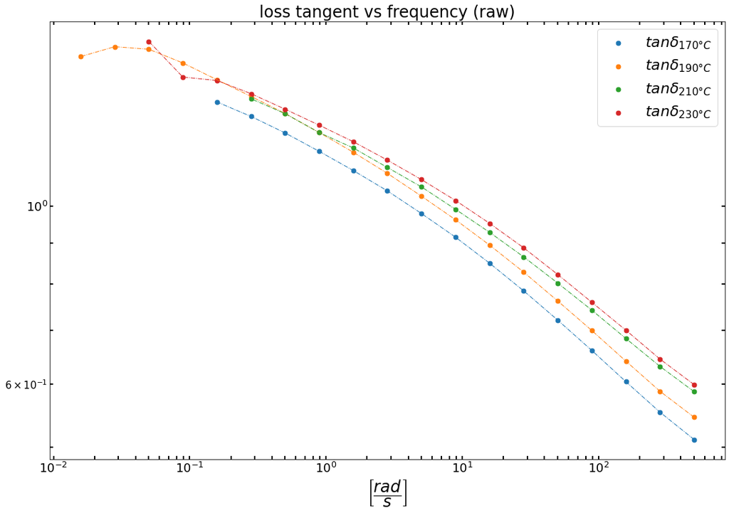

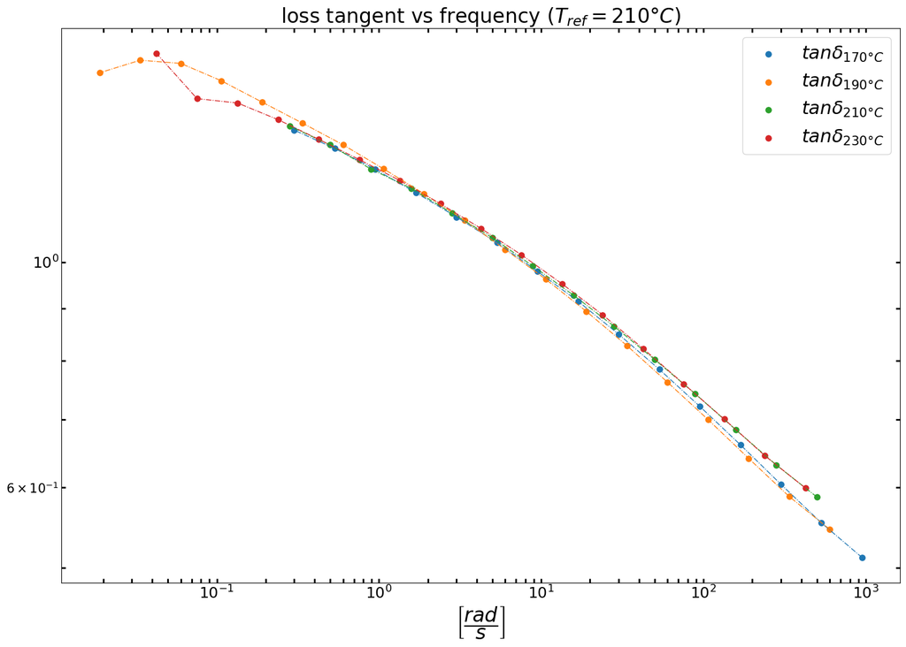

```python
jbr.plot(
    dataframe = df,
    pltname   = "loss tangent vs frequency (raw)",
    x_str     = ["$\omega_{170°C}$", "$\omega_{190°C}$", "$\omega_{210°C}$", "$\omega_{230°C}$"],
    x_units   = r"$\left[ \dfrac{rad}{s} \right]$",
    y_str     = ["${tan\delta}_{170°C}$", "${tan\delta}_{190°C}$", "${tan\delta}_{210°C}$", "${tan\delta}_{230°C}$"],
    y_units   = "")

jbr.plot(
    dataframe = df,
    pltname   = "loss tangent vs frequency (" + r'$T_{ref} = 210°C$' + ")",
    x_str     = ["$a_T \omega_{170°C}$", "$a_T \omega_{190°C}$", "$a_T \omega_{210°C}$", "$a_T \omega_{230°C}$"],
    x_units   = r"$\left[ \dfrac{rad}{s} \right]$",
    y_str     = ["${tan\delta}_{170°C}$", "${tan\delta}_{190°C}$", "${tan\delta}_{210°C}$", "${tan\delta}_{230°C}$"],
    y_units   = "")
```

### Plot $\tan \delta$ vs. $G^*(\omega)$ for each $T$

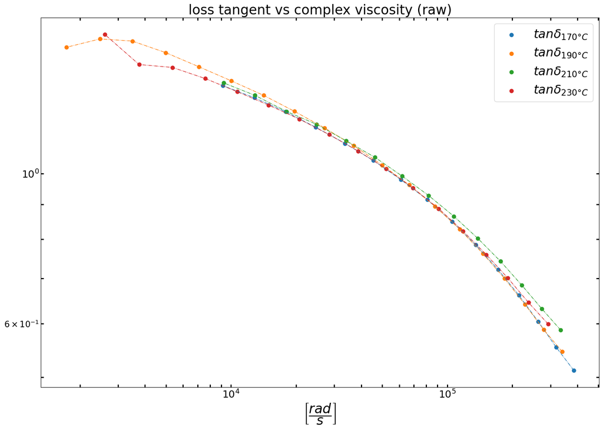

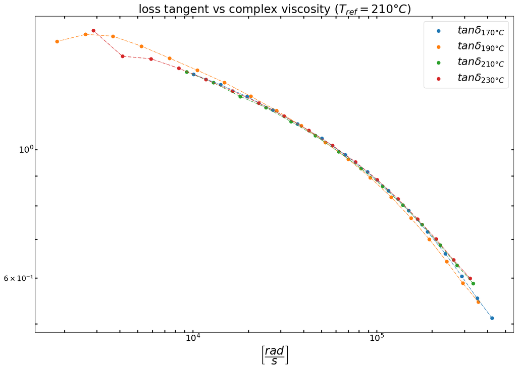

```python
jbr.plot(
    dataframe = df,
    pltname   = "loss tangent vs complex viscosity (raw)",
    x_str     = ["${G^{*}(\omega)}_{170°C}$", "${G^{*}(\omega)}_{190°C}$", "${G^{*}(\omega)}_{210°C}$", "${G^{*}(\omega)}_{230°C}$"],
    x_units   = r"$\left[ \dfrac{rad}{s} \right]$",
    y_str     = ["${tan\delta}_{170°C}$", "${tan\delta}_{190°C}$", "${tan\delta}_{210°C}$", "${tan\delta}_{230°C}$"],
    y_units   = "")

jbr.plot(
    dataframe = df,
    pltname   = "loss tangent vs complex viscosity (" + r'$T_{ref} = 210°C$' + ")",
    x_str     = ["$b_T {G^{*}(\omega)}_{170°C}$", "$b_T {G^{*}(\omega)}_{190°C}$", "$b_T {G^{*}(\omega)}_{210°C}$", "$b_T {G^{*}(\omega)}_{230°C}$"],
    x_units   = r"$\left[ \dfrac{rad}{s} \right]$",
    y_str     = ["${tan\delta}_{170°C}$", "${tan\delta}_{190°C}$", "${tan\delta}_{210°C}$", "${tan\delta}_{230°C}$"],
    y_units   = "")
```

### Get the activation energy $E_H$ and $E_V$

### $$ \log a_T \textit{ & } \log b_T \textit{ vs. } \left( \frac{1}{T} - \frac{1}{T_0} \right) $$

### Plot $\log a_T$ and $\log b_T$ vs. $\left( \frac{1}{T} - \frac{1}{T_0} \right)$ and fit a linear regression to get $E_H$ and $E_V$

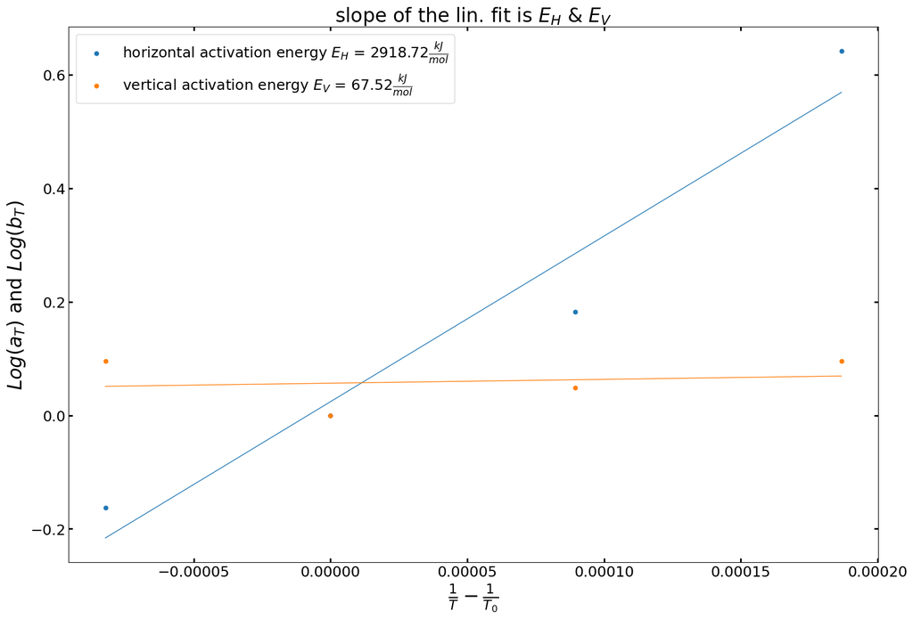

```python
# Declare sample temperatures in Celsius and Kelvin
T_C    = pd.Series([170, 190, 210, 230]);
T_K    = T_C + 273.15;
T_Cref = T_C[2];
T_Kref = T_K[2];

E_H, E_V = jbr.calculate_activationEnergies(T_K, T_Kref, aT, bT)
```

### Compute the shift factor $a_T$ for arbitrary temperatures with the Williams-Landell-Ferry (WLF) equation

### $$ a_T = \exp \left[ E_H \left( \frac{1}{T} - \frac{1}{T_0} \right) \right] $$

### $$ b_T = \exp \left[ E_V \left( \frac{1}{T} - \frac{1}{T_0} \right) \right] $$

```python
newTemperature = 200
aT_temp = jbr.calculate_shiftFactorWithWLF(E_H, newTemperature + 273.15, T_Kref)
bT_temp = jbr.calculate_shiftFactorWithWLF(E_V, newTemperature + 273.15, T_Kref)

aT = aT.append(pd.Series([aT_temp]));
bT = bT.append(pd.Series([bT_temp]));
T_C = T_C.append(pd.Series([newTemperature]));
T_K = T_C + 273.15;

display('a_T'); display(aT);
display('b_T'); display(bT);
display('T_C'); display(T_C);
```

```
'a_T'
```

```
0    1.900000
1    1.200000
2    1.000000
3    0.850000
0    1.136186
dtype: float64
```

```
'b_T'
```

```
0    1.100000
1    1.050000
2    1.000000
3    1.100000
0    1.002958
dtype: float64
```

```
'T_C'
```

```
0    170
1    190
2    210
3    230
0    200
dtype: int64
```

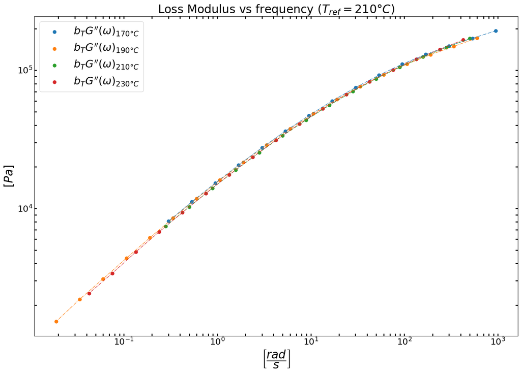

```python
jbr.plot(
    dataframe = df,
    pltname   = "Loss Modulus vs frequency (" + r'$T_{ref} = 210°C$' + ")",
    x_str     = ["$a_T \omega_{170°C}$", "$a_T \omega_{190°C}$", "$a_T \omega_{210°C}$", "$a_T \omega_{230°C}$"],
    x_units   = r"$\left[ \dfrac{rad}{s} \right]$",
    y_str     = ["$b_T {G^{\prime\prime}(\omega)}_{170°C}$", "$b_T {G^{\prime\prime}(\omega)}_{190°C}$", "$b_T {G^{\prime\prime}(\omega)}_{210°C}$", "$b_T {G^{\prime\prime}(\omega)}_{230°C}$"],
    y_units   = r"$\left[ Pa \right]$")
```

### Calculate complex viscosity master curve at $210°C$:

### $$ \eta^*(\omega) = \frac{G^*(\omega)}{\omega} $$

```python
df = jbr.calculate_complexViscosity(df)
df = df.reindex(sorted(df.columns), axis=1);
print("./data.csv"); display(df.head());
#display(pd.Series(df.columns));
```

```
./data.csv
```

|  | $\dot{\gamma}_{210°C}$ | $\omega_{170°C}$ | $\omega_{190°C}$ | $\omega_{210°C}$ | $\omega_{230°C}$ | $a_T \omega_{170°C}$ | $a_T \omega_{190°C}$ | $a_T \omega_{210°C}$ | $a_T \omega_{230°C}$ | $b_T {G^{*}(\omega)}_{170°C}$ | $b_T {G^{*}(\omega)}_{190°C}$ | $b_T {G^{*}(\omega)}_{210°C}$ | $b_T {G^{*}(\omega)}_{230°C}$ | $b_T {G^{\prime\prime}(\omega)}_{170°C}$ | $b_T {G^{\prime\prime}(\omega)}_{190°C}$ | $b_T {G^{\prime\prime}(\omega)}_{210°C}$ | $b_T {G^{\prime\prime}(\omega)}_{230°C}$ | ${G^{*}(\omega)}_{170°C}$ | ${G^{*}(\omega)}_{190°C}$ | ${G^{*}(\omega)}_{210°C}$ | ${G^{*}(\omega)}_{230°C}$ | ${G^{\prime\prime}(\omega)}_{170°C}$ | ${G^{\prime\prime}(\omega)}_{190°C}$ | ${G^{\prime\prime}(\omega)}_{210°C}$ | ${G^{\prime\prime}(\omega)}_{230°C}$ | ${G^{\prime}(\omega)}_{170°C}$ | ${G^{\prime}(\omega)}_{190°C}$ | ${G^{\prime}(\omega)}_{210°C}$ | ${G^{\prime}(\omega)}_{230°C}$ | … |
| --- | --- | --- | --- | --- | --- | --- | --- | --- | --- | --- | --- | --- | --- | --- | --- | --- | --- | --- | --- | --- | --- | --- | --- | --- | --- | --- | --- | --- | --- | --- |
| 0 | 5000.000 | 500.000 | 500.000 | 500.000 | 500.000 | 950.0000 | 600.0000 | 500.000 | 425.00000 | 423351.529467 | 356790.018207 | 334575.384489 | 322221.071579 | 192801.4 | 170824.500 | 169359.0 | 165566.50 | 384865.026789 | 339800.017340 | 334575.384489 | 292928.246890 | 175274.0 | 162690.0 | 169359.0 | 150515.0 | 342637.0 | 298322.0 | 288545.0 | 251301.0 | … |
| 1 | 2000.000 | 281.172 | 281.172 | 281.172 | 281.172 | 534.2268 | 337.4064 | 281.172 | 238.99620 | 351322.974343 | 293716.961184 | 273645.435089 | 261400.224173 | 170086.4 | 148797.600 | 146049.0 | 141611.80 | 319384.522130 | 279730.439223 | 273645.435089 | 237636.567430 | 154624.0 | 141712.0 | 146049.0 | 128738.0 | 279460.0 | 241178.0 | 231412.0 | 199744.0 | … |
| 2 | 1000.000 | 158.117 | 158.117 | 158.117 | 158.117 | 300.4223 | 189.7404 | 158.117 | 134.39945 | 289947.665877 | 239926.351298 | 221232.179009 | 209993.565704 | 149901.4 | 129436.650 | 124870.0 | 120453.30 | 263588.787161 | 228501.286950 | 221232.179009 | 190903.241549 | 136274.0 | 123273.0 | 124870.0 | 109503.0 | 225629.0 | 192397.0 | 182623.0 | 156375.0 | … |
| 3 | 500.000 | 88.916 | 88.916 | 88.916 | 88.916 | 168.9404 | 106.6992 | 88.916 | 75.57860 | 235901.453985 | 193218.652352 | 176238.437990 | 166724.036502 | 130040.9 | 110763.450 | 105000.0 | 100774.96 | 214455.867259 | 184017.764145 | 176238.437990 | 151567.305910 | 118219.0 | 105489.0 | 105000.0 | 91613.6 | 178929.0 | 150780.0 | 141545.0 | 120746.0 | … |
| 4 | 281.172 | 50.002 | 50.002 | 50.002 | 50.002 | 95.0038 | 60.0024 | 50.002 | 42.50170 | 189137.072925 | 153356.264002 | 138523.118588 | 130304.462223 | 110598.4 | 92915.235 | 86653.8 | 82735.18 | 171942.793568 | 146053.584764 | 138523.118588 | 118458.602021 | 100544.0 | 88490.7 | 86653.8 | 75213.8 | 139482.0 | 116194.0 | 108073.0 | 91516.8 | … |

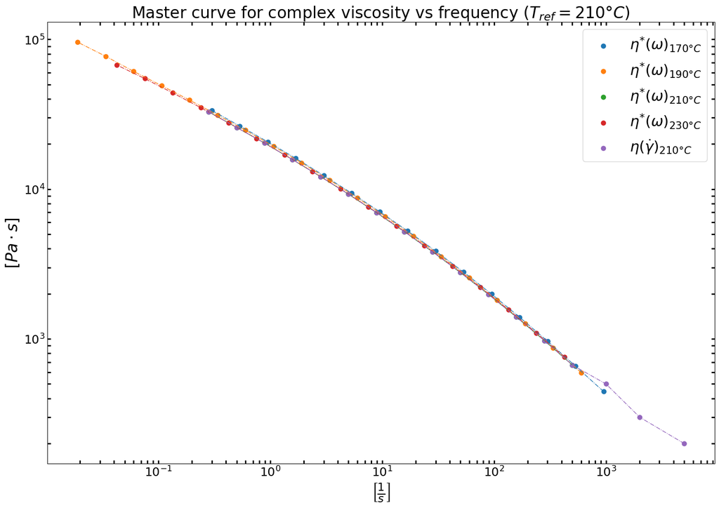

```python
jbr.plot(
    dataframe = df,
    pltname   = "Master curve for complex viscosity vs frequency (" + r'$T_{ref} = 210°C$' + ")",
    x_str     = ["$a_T \omega_{170°C}$", "$a_T \omega_{190°C}$", "$a_T \omega_{210°C}$", "$a_T \omega_{230°C}$", "$\dot{\gamma}_{210°C}$"],
    x_units   = r"$\left[ \frac{1}{s} \right]$",
    y_str     = ["${\eta^{*}(\omega)}_{170°C}$", "${\eta^{*}(\omega)}_{190°C}$", "${\eta^{*}(\omega)}_{210°C}$", "${\eta^{*}(\omega)}_{230°C}$", "${\eta(\dot{\gamma})}_{210°C}$"],
    y_units   = r"$\left[ Pa \cdot s \right]$")
```

## Plot complex viscosity vs frequency @different temperatures

```python
df_master_eta = pd.DataFrame()
df_master_G2 = pd.DataFrame()

tempStr=210; a=1; b=1;
master_omega_eta, master_eta, master_omega_G2, master_G2 = jbr.get_masterCurveData(df, tempStr, a, b);
df_master_eta["$_{master} \omega_{" + str(tempStr) + "°C}$"] = master_omega_eta
df_master_eta["$_{master} {\eta^{*}(\omega)}_{" + str(tempStr) + "°C}$"] = master_eta
df_master_G2["$_{master} \omega_{" + str(tempStr) + "°C}$"] = master_omega_G2
df_master_G2["$_{master} {G^{\prime\prime}(\omega)}_{" + str(tempStr) + "°C}$"] = master_G2

tempStr=200; a=float(aT.take([-1])); b=float(bT.take([-1]));
master_omega_eta, master_eta, master_omega_G2, master_G2 = jbr.get_masterCurveData(df, tempStr, a, b);
df_master_eta["$_{master} \omega_{" + str(tempStr) + "°C}$"] = master_omega_eta
df_master_eta["$_{master} {\eta^{*}(\omega)}_{" + str(tempStr) + "°C}$"] = master_eta
df_master_G2["$_{master} \omega_{" + str(tempStr) + "°C}$"] = master_omega_G2
df_master_G2["$_{master} {G^{\prime\prime}(\omega)}_{" + str(tempStr) + "°C}$"] = master_G2

df_master_eta = df_master_eta.sort_values("$_{master} \omega_{210°C}$")
df_master_G2  = df_master_G2.sort_values("$_{master} \omega_{210°C}$")

df_master_eta.to_csv('df_masterCurve_eta.csv', index=False)
df_master_G2.to_csv('df_masterCurve_G2.csv', index=False)

print("master curves"); display(df_master_eta.head());
display(pd.Series(df_master_eta.columns));
print("master curves"); display(df_master_G2.head());
display(pd.Series(df_master_G2.columns));
```

```
master curves
```

|  | $_{master} \omega_{210°C}$ | $_{master} {\eta^{*}(\omega)}_{210°C}$ | $_{master} \omega_{200°C}$ | $_{master} {\eta^{*}(\omega)}_{200°C}$ |
| --- | --- | --- | --- | --- |
| 18 | 0.018978 | 95767.332524 | 0.021562 | 96050.627808 |
| 17 | 0.033747 | 77135.439503 | 0.038343 | 77363.618628 |
| 16 | 0.042507 | 67425.861368 | 0.048296 | 67625.317988 |
| 16 | 0.060011 | 61133.203529 | 0.068183 | 61314.045448 |
| 15 | 0.075589 | 54685.608367 | 0.085883 | 54847.377255 |

```
0                $_{master} \omega_{210°C}$
1    $_{master} {\eta^{*}(\omega)}_{210°C}$
2                $_{master} \omega_{200°C}$
3    $_{master} {\eta^{*}(\omega)}_{200°C}$
dtype: object
```

```
master curves
```

|  | $_{master} \omega_{210°C}$ | $_{master} {G^{\prime\prime}(\omega)}_{210°C}$ | $_{master} \omega_{200°C}$ | $_{master} {G^{\prime\prime}(\omega)}_{200°C}$ |
| --- | --- | --- | --- | --- |
| 18 | 0.018978 | 1523.4135 | 0.021562 | 1527.920004 |
| 17 | 0.033747 | 2200.1490 | 0.038343 | 2206.657397 |
| 16 | 0.042507 | 2433.0570 | 0.048296 | 2440.254377 |
| 16 | 0.060011 | 3094.2870 | 0.068183 | 3103.440402 |
| 15 | 0.075589 | 3402.4100 | 0.085883 | 3412.474880 |

```
0                        $_{master} \omega_{210°C}$
1    $_{master} {G^{\prime\prime}(\omega)}_{210°C}$
2                        $_{master} \omega_{200°C}$
3    $_{master} {G^{\prime\prime}(\omega)}_{200°C}$
dtype: object
```

### Plot complex viscosity vs frequency @different temperatures

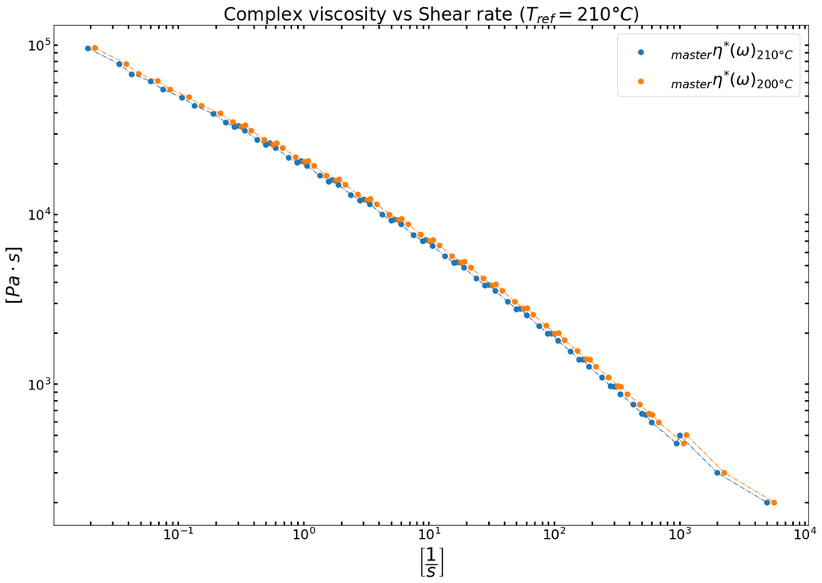

```python
jbr.plot(
    dataframe = df_master_eta,
    pltname   = "Complex viscosity vs Shear rate (" + r'$T_{ref} = 210°C$' + ")",
    x_str     = ["$_{master} \omega_{210°C}$", "$_{master} \omega_{200°C}$"],
    x_units   = r"$\left[ \dfrac{1}{s} \right]$",
    y_str     = ["$_{master} {\eta^{*}(\omega)}_{210°C}$", "$_{master} {\eta^{*}(\omega)}_{200°C}$"],
    y_units   = r"$\left[ Pa \cdot s \right]$")

#jbr.plot(
#    dataframe = df_master_G2,
#    pltname   = "Loss modulus vs Shear rate (" + r'$T_{ref} = 210°C$' + ")",
#    x_str     = ["$_{master} \omega_{210°C}$", "$_{master} \omega_{200°C}$"],
#    x_units   = r"$\left[ \dfrac{1}{s} \right]$",
#    y_str     = ["$_{master} {G^{\prime\prime}(\omega)}_{210°C}$", "$_{master} {G^{\prime\prime}(\omega)}_{200°C}$"],
#    y_units   = r"$\left[ Pa \right]$")
```

### Compute fitting curve with the Wagner model with the master curve at $210°C$

### Shear viscosity as a function of a given shear rate $\dot{\gamma}_o$

### $$ \eta (t, \dot{\gamma}_o) = f_1 \sum_{i=1}^{n} \frac{a_i}{{\alpha_i}^2} \left( 1 - e^{1 - \alpha_i t} (1 - \dot{\gamma}_o n_1 \lambda_i \alpha_i t) \right) + f_2 \sum_{i=1}^{n} \frac{a_i}{{\beta_i}^2} \left( 1 - e^{1 - \beta_i t} (1 - \dot{\gamma}_o n_2 \lambda_i \beta_i t) \right) $$

#### where:

#### $$ f_2 = 1 - f_1 $$

#### $$ \alpha_i = \frac{1 + n_1 \lambda_i \dot{\gamma}_o}{\lambda_i} $$

#### $$ \beta_i = \frac{1 + n_2 \lambda_i \dot{\gamma}_o}{\lambda_i} $$

$\eta (t, \dot{\gamma}_o) =$ shear viscosity  
$t =$ time  
$\dot{\gamma}_o =$ shear rate  
$a_i =$ the $i^{th}$ elastic value of the Maxwell element  
$\lambda_i =$ the $i^{th}$ characteristic time of the Maxwell element  
$f_1, f_2, n_1, n_2$ are fitting parameters

### The Wagner model gives the shear viscosity vs. time of a single shear rate ...

### The steady state shear viscocity at several shear rates at $t = \infty$ is given by:

### $$ \eta (t = \infty, \dot{\gamma}_o) = f_1 \sum_{1=1}^{n} \frac{a_i}{{\alpha_i}^2} + f_2 \sum_{1=1}^{n} \frac{a_i}{{\beta_i}^2} $$

```
[2.68425342e+08 1.09191259e+06 2.57623389e+05 9.67069909e+03
 2.04877643e+02 8.96633937e-03 1.74375415e-01 1.74521550e-01
 6.30348573e+00 8.07822062e+01 8.89712169e-01 4.69519418e-01
 4.83767742e-03]
```

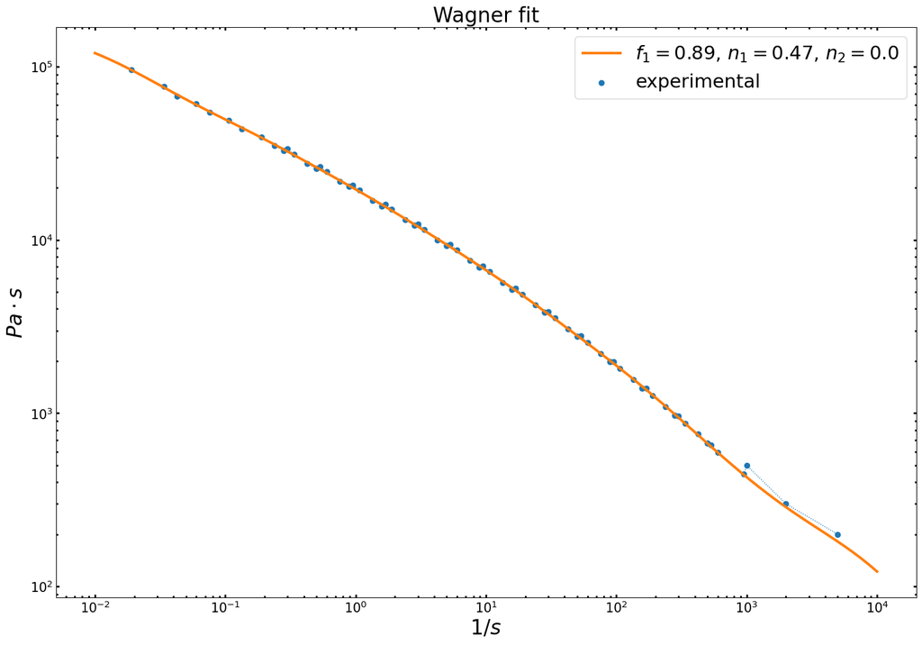

```python
parameters = jbr.plot_Wagner_fit(
    df_master_eta,
    "$_{master} \omega_{210°C}$",
    "$_{master} {\eta^{*}(\omega)}_{210°C}$")
```

### Steady state first normal stress difference $N1$ at $t = \infty$

### $$ N1(t, \dot{\gamma}_o) = {\dot{\gamma}_o}^2 \left\{ f_1 \sum_{i=1}^{n} a_i {\alpha_i}^3 \left( 1 - e^{- \alpha_i t} \left[ 1 + \alpha_i t - {\alpha_i}^2 \left( n_1 \lambda_i \frac{\dot{\gamma}_o}{2} \right) t^2 \right) \right] + f_2 \sum_{i=1}^{n} a_i {\beta_i}^3 \left( 1 - e^{- \beta_i t} \left[ 1 + \beta_i t - {\beta_i}^2 \left( n_2 \lambda_i \frac{\dot{\gamma}_o}{2} \right) t^2 \right) \right] \right\} $$

### $$ N1(t=\infty, \dot{\gamma}_o) = {\dot{\gamma}_o}^2 \left\{ f_1 \sum_{i=1}^{n} a_i {\alpha_i}^3 + f_2 \sum_{i=1}^{n} a_i {\beta_i}^3 \right\} $$

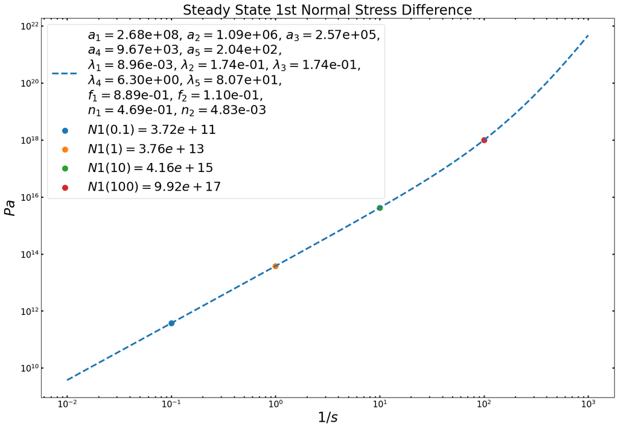

```python
jbr.plot_steadyStateN1(parameters)
```